# Statistique Descriptive

Description des données

Le jeu de données dont nous disposons est une base de données SNCF, décrivant les défauts présents sur la voie ferrée. Ces données sont présentées en fichiers csv, sur un historique de 17 ans sur une région du nord de l’Ile de France.

Chaque ligne du fichier contient un défaut unique observé et enregistré, ainsi que les caractéristiques techniques des rails, telles que :

**Ligne** : Numéro de la ligne ferrée

**NOMVOIE** :Nom de la voie

**ID_DEFAUT** : Identifiant unique du défaut

**PK_DEFAUT** : Point kilométrique du défaut

**PROFIL_RAIL** : Caractéristiques techniques des rails qui se regroupent en 5 catégories :

- Autre
- 46-E2
- 50-E6
- 55-E1
- 60-E1

**ANNEE_POSE** : Année de pose du rail

**VITESSE** : Vitesse maximale autorisée des circulations

- Forte densité de circulation
- Densité moyenne de circulation
- Faible densité de circulation

**RAYON_COURBE** : Indique si la voie est en ligne droite ou circulaire.

**TYPE_EMPLACEMENT** : Indique l’emplacement de la voie, si elle est dans un tunnel ou à l’éxtérieur.

**Annee_Decouverte** : Année de découverte du défaut.

**Age du rail** : âge du rail au moment où on observe le défaut.

Ces modalités décrivent le niveau de fissuration de la voie :

- E : N’évolue pas en fissuration, défauts de surface du rail ou d’usure ondulatoire (déforme le rail => gène et abîme le train)
- NR : Provoque des fissurations mais le rail peut rester en voie, avec ou sans surveillance, Gravité 1
- O : Provoque des fissurations mais le rail peut rester en voie, avec ou sans surveillance, Gravité 2
- X1 : Provoque des fissurations et demande des mesures de sécurité, Risque de rupture faible
- X2 : Provoque des fissurations et demande des mesures de sécurité, Risque de rupture important
- S : Provoque des fissurations et demande des mesures de sécurité, Risque de rupture imminent

Les données sous la forme du tableau ci-dessous :

Les données initiales sont dans TAB

```r
head(TAB)
```

|  | ID_DEFAUT | LIGNE | VOIE_bis | METRE | ANNEE_POSE | Profil | VITESSE | GROUPE_UIC | RAYON_COURBE | TYPE_CLASSEMENT | EMPLACEMENT | ANNEE_DECOUVERTE | AGE | RANG | AGE_bis | VITESSE_bis | TR_ANNEE_POSE | TYPE_RAYON_COURBE |
| --- | --- | --- | --- | --- | --- | --- | --- | --- | --- | --- | --- | --- | --- | --- | --- | --- | --- | --- |
| 1 | 14378 | 990000 | V2 | 61421 | 1979 | 50-E6 | 70 | 2 | 480 | O | Ciel ouvert | 2006 | 27 | 2 | (20,30] | (50,100] | (1.97e+03,1.98e+03] | COURBE |
| 2 | 14491 | 990000 | V1 | 60180 | 1977 | 50-E6 | 70 | 2 | 0 | O | Ciel ouvert | 2006 | 29 | 2 | (20,30] | (50,100] | (1.97e+03,1.98e+03] | ALIGNEMENT |
| 3 | 14610 | 990000 | V1 | 61280 | 1977 | 50-E6 | 70 | 2 | NA | O | Ciel ouvert | 2007 | 30 | 2 | (20,30] | (50,100] | (1.97e+03,1.98e+03] | ALIGNEMENT |
| 4 | 14839 | 990000 | V1 | 61180 | 1977 | 50-E6 | 70 | 2 | 0 | X1 | Ciel ouvert | 2006 | 29 | 2 | (20,30] | (50,100] | (1.97e+03,1.98e+03] | ALIGNEMENT |
| 5 | 14898 | 990000 | V1 | 61575 | 1977 | 60-E1 | 70 | 2 | 500 | X1 | Ciel ouvert | 2007 | 30 | 2 | (20,30] | (50,100] | (1.97e+03,1.98e+03] | COURBE |
| 6 | 310270 | 272000 | VMO | 1190 | 1993 | 60-E1 | 60 | 6 | 0 | O | Ciel ouvert | 2007 | 14 | 1 | (10,20] | (50,100] | (1.99e+03,2e+03] | ALIGNEMENT |

```r
summary(TAB)
```

```
   ID_DEFAUT           LIGNE           VOIE_bis        METRE
 Min.   :  14378   Min.   :  1306   V1     :4252   Min.   :     2
 1st Qu.: 326217   1st Qu.:229000   V2     :3779   1st Qu.: 18044
 Median :2496284   Median :272000   V1BIS  :1085   Median : 29260
 Mean   :1904863   Mean   :279539   V2BIS  : 888   Mean   : 39531
 3rd Qu.:2802261   3rd Qu.:272000   UNIQUE : 579   3rd Qu.: 57129
 Max.   :3038632   Max.   :992300   V2L    : 108   Max.   :116175
                                    (Other):1208
   ANNEE_POSE      Profil             VITESSE       GROUPE_UIC
 Min.   : 197   Length:11899       Min.   :  0.0   Length:11899
 1st Qu.:1974   Class :character   1st Qu.:100.0   Class :character
 Median :1985   Mode  :character   Median :120.0   Mode  :character
 Mean   :1982                      Mean   :121.9
 3rd Qu.:1993                      3rd Qu.:160.0
 Max.   :2016                      Max.   :300.0
 NA's   :133
  RAYON_COURBE     TYPE_CLASSEMENT    EMPLACEMENT
 Min.   :    0.0   Length:11899       Length:11899
 1st Qu.:    0.0   Class :character   Class :character
 Median :    0.0   Mode  :character   Mode  :character
 Mean   :  568.6
 3rd Qu.:  485.0
 Max.   :99999.0
 NA's   :900
 ANNEE_DECOUVERTE      AGE               RANG           AGE_bis
 Min.   :2000     Min.   : -13.00   Min.   :1.000   (20,30] :4769
 1st Qu.:2007     1st Qu.:  21.00   1st Qu.:1.000   (30,40] :2326
 Median :2013     Median :  26.00   Median :1.000   (10,20] :1976
 Mean   :2011     Mean   :  29.77   Mean   :1.019   (40,50] :1135
 3rd Qu.:2016     3rd Qu.:  36.00   3rd Qu.:1.000   (-20,10]: 573
 Max.   :2017     Max.   :1805.00   Max.   :2.000   (Other) : 986
                  NA's   :133                       NA's    : 134
    VITESSE_bis               TR_ANNEE_POSE  TYPE_RAYON_COURBE
 (-10,50] : 626   (0,1.97e+03]       :2152   Length:11899
 (50,100] :2975   (1.97e+03,1.98e+03]:2342   Class :character
 (100,160]:7652   (1.98e+03,1.99e+03]:3408   Mode  :character
 (160,200]: 642   (1.99e+03,2e+03]   :3161
 (200,400]:   4   (2e+03,3e+03]      : 703
                  NA's               : 133
```

Observation graphique des variables :

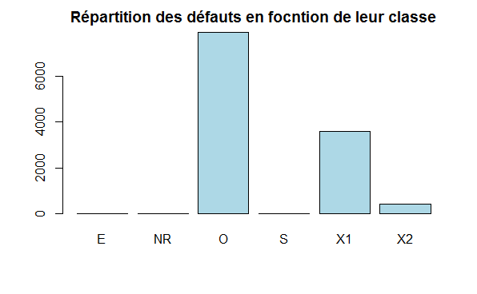

```r
barplot(table(TAB$TYPE_CLASSEMENT),col = "lightblue", main="Répartition des défauts en focntion de leur classe")
```

L’idée est donc de mener l’étude uniquement sur les trois classes significatifs : O : pas grave X1 : grave X2 : Très grave

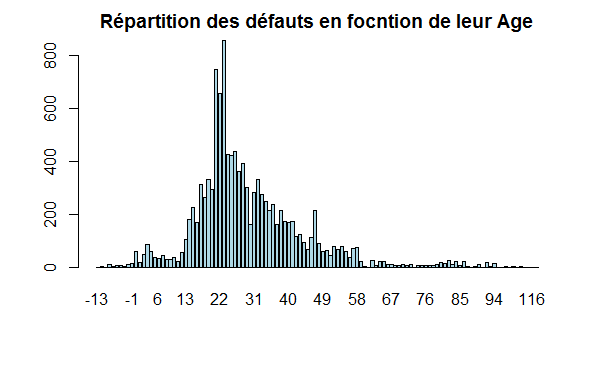

```r
barplot(table(TAB$AGE),col = "lightblue", main="Répartition des défauts en focntion de leur Age")
```

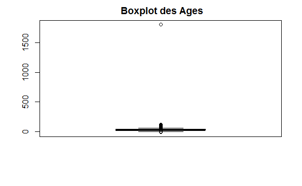

```r
boxplot(TAB$AGE,col = "lightblue", main=" Boxplot des Ages")
```

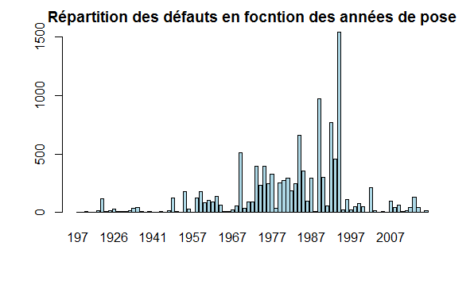

```r
barplot(table(TAB$ANNEE_POSE),col = "lightblue", main="Répartition des défauts en focntion des années de pose")
```

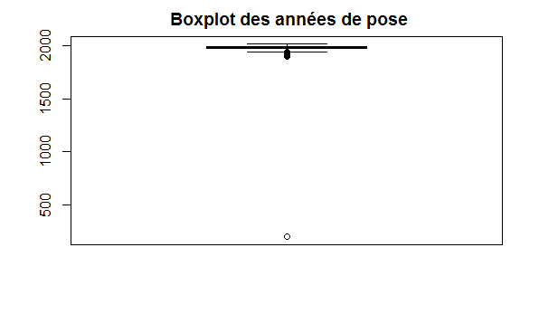

```r
boxplot(TAB$ANNEE_POSE,col = "lightblue", main=" Boxplot des années de pose")
```

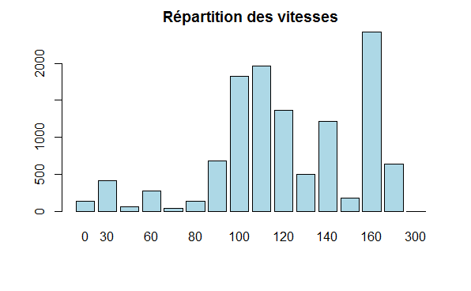

```r
barplot(table(TAB$VITESSE),col = "lightblue", main="Répartition des vitesses")
```

```r
par(mfrow=c(2,2))
barplot(table(TAB$Profil),col = "lightblue", main="Défaut/Type de rail")
barplot(table(TAB$TYPE_RAYON_COURBE),col = "lightblue", main="Défaut/Disposition de la voie ")
```

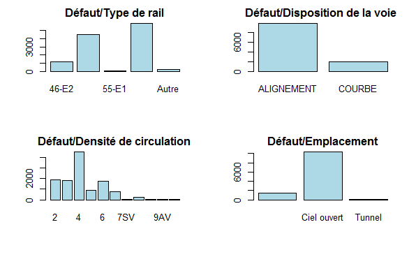

```r
barplot(table(TAB$GROUPE_UIC),col = "lightblue", main="Défaut/Densité de circulation")
barplot(table(TAB$EMPLACEMENT),col = "lightblue", main="Défaut/Emplacement")
```

Cet aperçu de données nous a permis de faire des choix sur les données telle que :

- Suppréssion de la valeur abbérante de la variable “Age” qui est égale à 1805. La présence des valeurs négatives et manquantes s’explique par de mauvaises saisie.L’idée donc était de re-croiser ces données avec d’autres bases de données (patrimoine notamment) afin de pouvoir compléter ces données. C’est vrai aussi pour la variable année de pose
- Enlever la variable emplacement de l’étude vu la peu de significativité qu’elle présente.
- Pour la densité de circulation, le groupement de certaines modalités dans un meme groupe est utile afin de construie que trois groupes :
- Forte densité
- Moyenne densité
- Faible densité

Les modifications apportées comme mentionné ci-dessus se resulte dans le tablea de données TAB_bis. Il faut noter que lors du croisement avec d’autres base, la detection d’une variable importante qui pourra apporter une interprétation aux données était ajoutée. Cette variable est Train, qui permet d’informer si le train est un TGV, un Transilien ou autre (fret,…).

```r
head(TAB_bis)
```

|  | ID_DEFAUT | LIGNE | VOIE_bis | METRE | ANNEE_POSE | Profil | VITESSE | TYPE_CLASSEMENT | EMPLACEMENT | AGE | RANG | AGE_bis | VITESSE_bis | TR_ANNEE_POSE | COURBE | TRAIN | UIC | Class_Binaire |
| --- | --- | --- | --- | --- | --- | --- | --- | --- | --- | --- | --- | --- | --- | --- | --- | --- | --- | --- |
| 1 | 14378 | 990000 | V2 | 61421 | 1979 | 50-E6 | 70 | O | Ciel ouvert | 27 | 2 | (20,30] | (50,100] | (1.97e+03,1.98e+03] | COURBE | NA | Forte Densite | 0 |
| 2 | 14491 | 990000 | V1 | 60180 | 1977 | 50-E6 | 70 | O | Ciel ouvert | 29 | 2 | (20,30] | (50,100] | (1.97e+03,1.98e+03] | ALIGNEMENT | NA | Forte Densite | 0 |
| 3 | 14610 | 990000 | V1 | 61280 | 1977 | 50-E6 | 70 | O | Ciel ouvert | 30 | 2 | (20,30] | (50,100] | (1.97e+03,1.98e+03] | ALIGNEMENT | NA | Forte Densite | 0 |
| 4 | 14839 | 990000 | V1 | 61180 | 1977 | 50-E6 | 70 | X1 | Ciel ouvert | 29 | 2 | (20,30] | (50,100] | (1.97e+03,1.98e+03] | ALIGNEMENT | NA | Forte Densite | 1 |
| 5 | 14898 | 990000 | V1 | 61575 | 1977 | 60-E1 | 70 | X1 | Ciel ouvert | 30 | 2 | (20,30] | (50,100] | (1.97e+03,1.98e+03] | COURBE | NA | Forte Densite | 1 |
| 6 | 310270 | 272000 | VMO | 1190 | 1993 | 60-E1 | 60 | O | Ciel ouvert | 14 | 1 | (10,20] | (50,100] | (1.99e+03,2e+03] | ALIGNEMENT | TRANSILIEN | Moyenne Densite | 0 |

```r
summary(TAB_bis)
```

```
   ID_DEFAUT           LIGNE           VOIE_bis        METRE
 Min.   :  14378   Min.   :  1306   V1     :4235   Min.   :     2
 1st Qu.: 326500   1st Qu.:229000   V2     :3774   1st Qu.: 18767
 Median :2502484   Median :272000   V1BIS  :1047   Median : 29366
 Mean   :1922609   Mean   :280033   V2BIS  : 818   Mean   : 39768
 3rd Qu.:2802341   3rd Qu.:272000   UNIQUE : 578   3rd Qu.: 57378
 Max.   :3038632   Max.   :992300   V2L    : 108   Max.   :116175
                                    (Other):1207
   ANNEE_POSE     Profil        VITESSE    TYPE_CLASSEMENT
 Min.   :1900   46-E2:1124   Min.   :  0   E :   2
 1st Qu.:1974   50-E6:4451   1st Qu.:100   NR:   1
 Median :1984   55-E1:   4   Median :120   O :7860
 Mean   :1982   60-E1:5824   Mean   :123   S :   2
 3rd Qu.:1993   Autre: 176   3rd Qu.:160   X1:3491
 Max.   :2016   NA's : 188   Max.   :300   X2: 411

 EMPLACEMENT             AGE              RANG         AGE_bis
 Length:11767       Min.   :  0.00   Min.   :1.00   (20,30]:4792
 Class :character   1st Qu.: 21.00   1st Qu.:1.00   (30,40]:2338
 Mode  :character   Median : 26.00   Median :1.00   (10,20]:1994
                    Mean   : 29.82   Mean   :1.02   (40,50]:1150
                    3rd Qu.: 36.00   3rd Qu.:1.00   (50,60]: 556
                    Max.   :116.00   Max.   :2.00   [0,10] : 505
                                                    (Other): 432
    VITESSE_bis               TR_ANNEE_POSE         COURBE
 (100,160]:7629   (0,1.97e+03]       :2151   ALIGNEMENT:9648
 (160,200]: 642   (1.97e+03,1.98e+03]:2343   COURBE    :2119
 (200,400]:   4   (1.98e+03,1.99e+03]:3409
 (50,100] :2975   (1.99e+03,2e+03]   :3161
 [0,50]   : 517   (2e+03,3e+03]      : 679
                  NA's               :  24

        TRAIN                   UIC       Class_Binaire
 Autre     :4214   Faible Densite :1051   Min.   :0.0000
 TGV       : 435   Forte Densite  :8089   1st Qu.:0.0000
 TRANSILIEN:7092   Moyenne Densite:2627   Median :0.0000
 NA's      :  26                          Mean   :0.3318
                                          3rd Qu.:1.0000
                                          Max.   :1.0000
```

Meme avec le croisement fait afin d’avoir plus d’informations et moins de valeurs manquantes, il reste encore quelques observation manquantes. L’idée est de faire une ACP et une AFC afin de visualiser le comportement de ces observations.

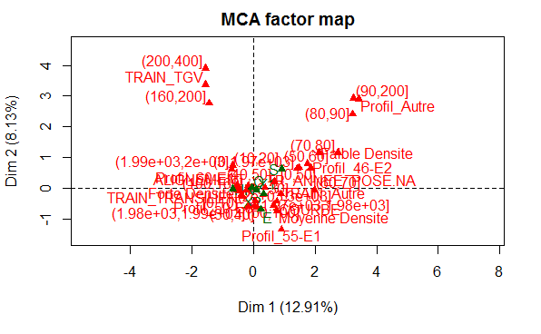

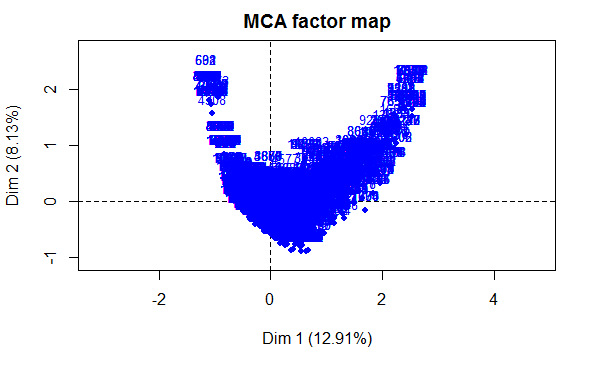

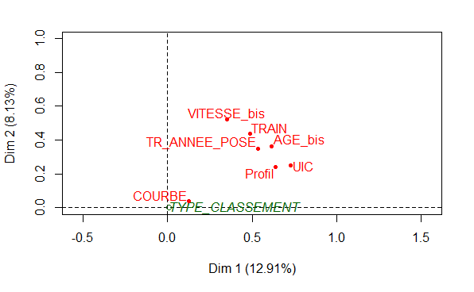

```r
t<-TAB_bis[,c(6,8,12,13,14,15,16,17)]
MOD_mca<-MCA(t,quali.sup = 2)
```

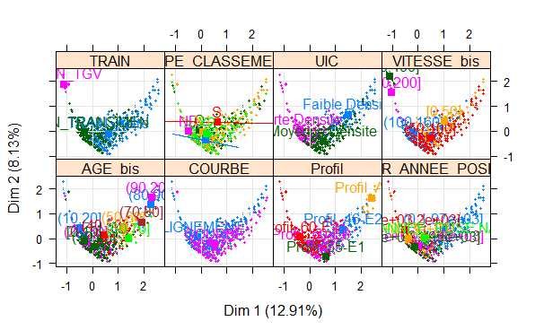

```r
#MOD_mca3<-MCA(t[complete.cases(t), ], ncp = 5, graph = FALSE)
plotellipses(MOD_mca)
```

```r
#plotellipses(MOD_mca3)
```

Ce graphe montre l’explication de l’ensemble de nos données sur leur deux premières composantes principales (done l’explication n’est pas importante).

[figure not shown]

```r
eig.val <- MOD_mca$eig
barplot(eig.val[, 2],
        names.arg = 1:nrow(eig.val),
        main = "Variances Explained by Dimensions (%)",
        xlab = "Principal Dimensions",
        ylab = "Percentage of variances",
        col ="steelblue")
# Add connected line segments to the plot
lines(x = 1:nrow(eig.val), eig.val[, 2],
      type = "b", pch = 19, col = "red")
```

Focalisons nous sur les variables ayants des valeurs manquantes: Age,Train Année_pose et Profil.

[figure not shown]

```r
plotellipses(MOD_mca,keepvar = 1)
```

[figure not shown]

```r
plotellipses(MOD_mca,keepvar = 1,invisible="ind")
```

```r
head(MOD_mca$var$coord)
```

```
                   Dim 1      Dim 2      Dim 3      Dim 4      Dim 5
Profil.NA     0.03583249 -0.5586848 -0.2571450  2.2304111 -0.2788553
Profil_46-E2  1.86080531  0.6620086 -0.6169736 -0.2310719 -1.1959951
Profil_50-E6  0.06482469 -0.3993031  0.5132987  0.3138687 -0.1946275
Profil_55-E1  0.91816634 -1.3262663  1.5920119 -0.5002883  0.3054519
Profil_60-E1 -0.51212561  0.1065684 -0.2767556 -0.2984718  0.2067141
Profil_Autre  3.36437770  2.9709310  0.3556015  1.0436291  6.0107140
```

```r
TAB_bis$Profil[is.na(TAB_bis$Profil)]<-"50-E6"
TAB_bis$Profil<-factor(TAB_bis$Profil)
## donc on l'a supprime afin de ne pas l'affecter à une valeur fausse : 26 NA
TAB_bis<-TAB_bis[-which(is.na(TAB_bis$TRAIN)),]
rownames(TAB_bis)<-NULL
TAB_bis$TRAIN<-factor(TAB_bis$TRAIN)
```

Après le netoyage des données et la comprehesion des relations etre ces variables, on passe à la modélisation. Déclarons la BASE_TRAVAIL est la base netoyée et préprée pour l’étude.

```r
BASE_TRAVAIL<-TAB_bis
```